# Web Scraping mit R

Workshop an der Universität Hamburg

Fabian Gülzau (HU Berlin)

16 Januar 2019

## Inhalt

> “If programming is magic, then web scraping is wizardry” ([Mitchell 2015: vii](http://shop.oreilly.com/product/0636920034391.do))
1. Einleitung
2. Technologien des WWW
3. Web Scraping (Toolbox)
   1. Generelles Schema
   2. Spezielle Technologien
4. Rechtliche Aspekte
5. Weitere Beispiele und Anwendungen

## Zur Präsentation

- Folien sind online verfügbar: https://goo.gl/erTCX7
  - Folien im Browser öffnen
- Beispiele auf [GitHub](https://github.com/FabianFox/Webscraping-Hamburg-)
- Benötigte Pakete über:

```r
install.packages(pacman) # Installation nur einmal notwendig
library(pacman)
p_load(tidyverse, rvest, httr, robotstxt, eurostat, lubridate)
```

## 1. Einleitung

> “…something big is going on” ([Salganik 2018: 2](https://www.bitbybitbook.com/en/1st-ed/preface/))
- Übergang vom analogen zum digitalen Zeitalter
  - kommende Krise der empirischen Soziologie ([Savage & Burrows 2007](https://journals.sagepub.com/doi/10.1177/0038038507080443#articleShareContainer))?
  - neue Möglichkeiten und/oder Gefahren ([Salganik 2018: 17-41](https://www.bitbybitbook.com/en/1st-ed/observing-behavior/characteristics/))

> “‘computational social science’ (CSS) is occurring. The question is whether it happens with or without social scientists” ([Heiberger & Riebling 2016: 1](https://journals.sagepub.com/doi/abs/10.1177/2059799115622763))

## Neue Möglichkeiten: Beispiele

Exemplarische Studien:

- King et al. (2013) [“How Censorship in China Allows Government Criticism but Silences Collective Expression”](http://bit.ly/2E1Yjhc)
- Budak & Watts (2015) [“Dissecting the Spirit of Gezi: Influence vs. Selection in the Occupy Gezi Movement”](https://www.sociologicalscience.com/articles-v2-18-370/)
- Törnberg & Törnberg (2016) [“Combining CDA and topic modeling: Analyzing discursive connections between Islamophobia and anti-feminism on an online forum”](https://journals.sagepub.com/doi/abs/10.1177/0957926516634546#articleShareContainer)

## Zensur in China I

King et al. ([2013](http://bit.ly/2E1Yjhc)):

- **Frage**: Was wird zensiert?
- **Vorgehen**: Online-Beiträge erheben und prüfen, welche zensiert werden
- **Daten**: 11 Millionen Beiträge auf 1,382 Internetseiten
- **Ergebnisse**: Kritische Beiträge sind erlaubt; soziale Mobilisierung nicht

[figure not shown]

Chacha: Chinesische Internetpolizei

## Zensur in China II

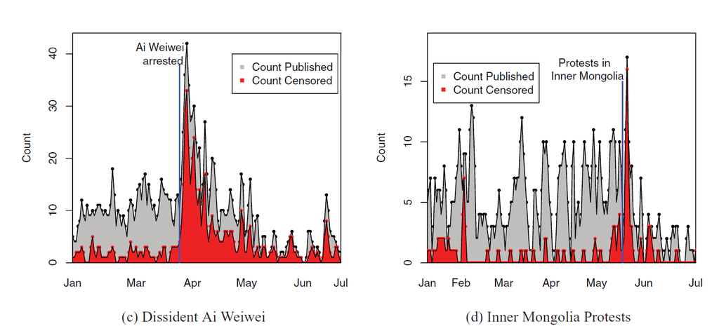

Quelle: [King et al. (2013: 335)](http://bit.ly/2E1Yjhc)

## Lehre

Studium.org ([Code](https://github.com/FabianFox/Webscraping-Hamburg-/blob/master/Code/SoziologieOrg-Scraper.R)):

- Informationen zu Soziologiestudiengängen
- z.B. Mietspiegel, Wetter, Kinos…

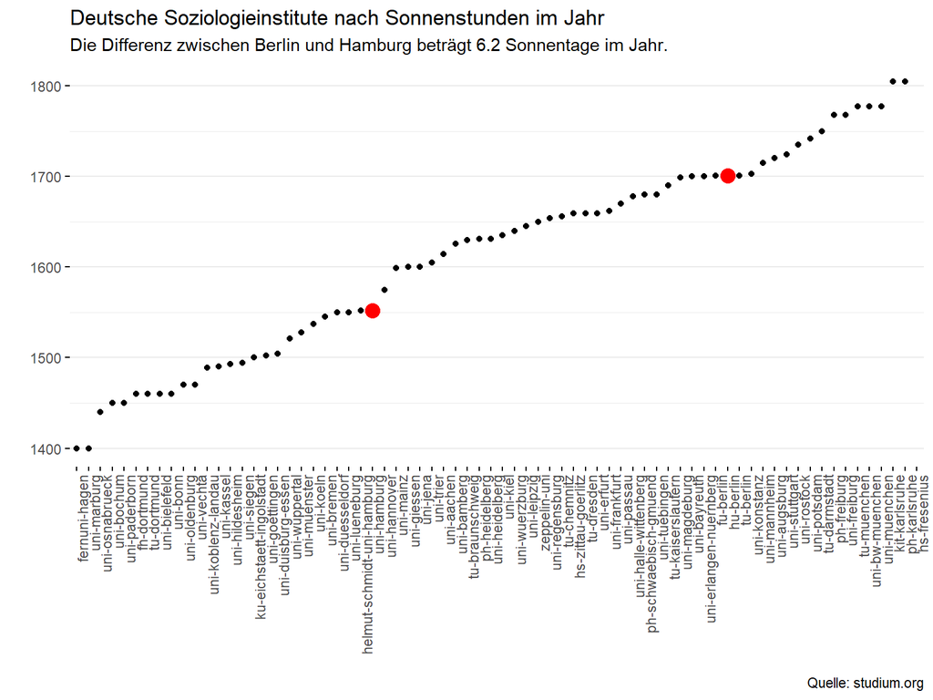

## Digitale Daten

- positiv: big, always-on, nonreactive
- negativ: incomplete, inaccessible, nonrepresentative, drifting, algorithmically confounded, sensitive

Quelle: [Salganik 2018: 17-41](https://www.bitbybitbook.com/en/1st-ed/observing-behavior/characteristics/)

## 2. Technologien des WWW

Infrastruktur des Internets im Alltag irrelevant.

Unser Browser übernimmt:

- Serveranfragen (Request/Response: HTTP)
- Darstellung von HTML, CSS und JavaScript

Um Informationen gezielt abzufragen, benötigen wir allerdings basale Kenntnisse der zugrundeliegenden Technologien.

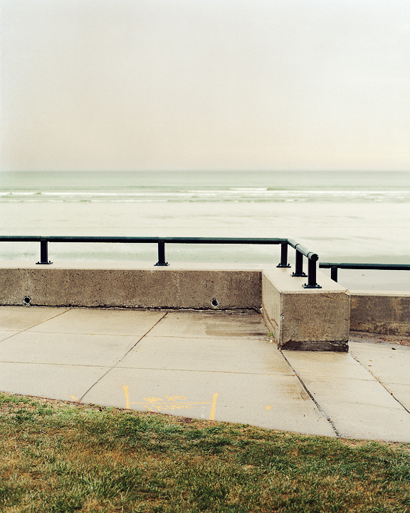

[Transatlantisches Seekabel](https://davegreer.cc/INTERNET)

## HTTP I

**H**yper**t**ext **T**ransfer **P**rotocol [(HTTP)](https://en.wikipedia.org/wiki/Hypertext_Transfer_Protocol)

[figure not shown]

- Übertragungsprotokoll, welches aus zwei Teilen besteht:
  - Request (Client)
  - Response (Server)

## HTTP II

- Requests erfolgen über **U**niform **R**esource **L**ocators [(URL)](https://en.wikipedia.org/wiki/URL)
  - Teile der URL können genutzt werden, um Informationen zu extrahieren

## Beispiel: HTTP I

- `GET`-Abfrage mit `httr::GET` und Antwort des Servers in R

```r
#install.packages("httr")
library(httr)
response <- GET("https://www.wiso.uni-hamburg.de/fachbereich-sozoek/professuren/lohmann/team/hertel-florian.html") %>%
  print()
```

```
## Response [https://www.wiso.uni-hamburg.de/fachbereich-sozoek/professuren/lohmann/team/hertel-florian.html]
##   Date: 2019-01-16 08:48
##   Status: 200
##   Content-Type: text/html; charset=utf-8
##   Size: 30.9 kB
## <!DOCTYPE html><html class="v4" lang="de" xml:lang="de" xmlns="http://ww...
## <meta name="csrf-token" content="q7cZCDWLVdlnp6YkwuRgJIwWG4OHaidCLliAuh4...
## <p>Anmeldungen bitte per Mail.</p><h3>Kontakt</h3><div class="telefon">T...
## <p><strong>Seit 09/2016<br /></strong>Wissenschaftlicher Mitarbeiter, Pr...
## <p><strong>09/2015-08/2016<br /></strong>Max Weber Postdoctoral Fellow, ...
## <p><strong>09/2010-10/2015<br /></strong>Affiliated Fellow, Bremen Inter...
## <p><strong>11/2009-07/2015<br /></strong>Wissenschaftlicher Mitarbeiter,...
## <p><strong>05/2009-10/2009<br /></strong>Wissenschaftlicher Mitarbeiter,...
## <p><strong>03/2009<br /></strong>Diplom Soziologie, Freie Universität Be...
## <li>Soziale Ungleichheit und Stratifikation</li>
## ...
```

## Beispiel: HTTP II

```r
#install.packages("rvest")
library(rvest)

pubs <- response %>%
  read_html() %>%
  html_nodes("#4128883 li") %>%
  html_text() %>%
  tibble(pub = .) %>%
  mutate(year = as.numeric(
    str_extract(pub, pattern = "[:digit:]{4}"))) %>%
  group_by(year) %>%
  summarise(number = n())
```

| year | number |
| --- | --- |
| 2009 | 1 |
| 2010 | 2 |
| 2011 | 1 |
| 2014 | 1 |
| 2015 | 2 |
| 2016 | 1 |
| 2017 | 2 |
| 2018 | 1 |

## HTML

**H**yper**t**ext **M**arkup **L**anguage [(HTML)](https://www.w3schools.com/html/default.asp)

- einfacher Text mit weiteren Anweisungen (Tags, Attributes…)
  - wird vom Browser interpretiert und dargestellt
- HTML-Code ist über die Webentwicklungstools des Browsers verfügbar
  - Rechtsklick -> Element untersuchen (Firefox)

## Beispiel: HTML I

Einfache Seiten über Editor/Notepad++ erstellbar:

```r
<!DOCTYPE html>
<html>

<head>
<title>Workshop Web Scraping</title>
</head>

<body>
<h1> Web Scraping mit R, Universit&auml;t Hamburg</h1>
<p>Dieser Kurs f&uuml;hrt in das "Web Scraping" mit R ein. Er wird durch <a href="https://fguelzau.rbind.io/">Fabian G&uuml;lzau</a> geleitet.</p>

</body>
</html>
```

Der Browser interpretiert den Code und zeigt eine [Internetseite](http://htmlpreview.github.io/?https://github.com/FabianFox/Webscraping-Hamburg-/blob/master/Code/HTML-Example.html) an.

## Beispiel: HTML II

HTML:

- hat eine Baumstruktur
- Markup-Elemente helfen uns Informationen zu lokalisieren (Relationalität)
  - **D**ocument **O**bject **M**odel [(DOM)](https://en.wikipedia.org/wiki/Document_Object_Model)
  - Darstellung von HTML in R (parsing)

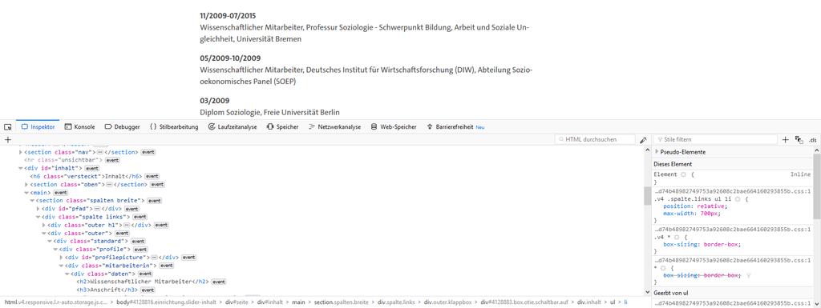

## CSS

**C**ascading **S**tyle **S**heet [(CSS)](https://www.w3schools.com/css/default.asp)

- beinhaltet Informationen über den Stil der HTML-Seite
- kann genutzt werden, um Informationen zu lokalisieren (CSS-Selektoren)

[figure not shown]

## JavaScript

[JavaScript](https://www.w3schools.com/js/default.asp): Programmiersprache des Internets

- macht Internetseiten dynamisch
- Inhalte erscheinen erst nach Ausführung von JS
  - problematisch für unsere Scraper

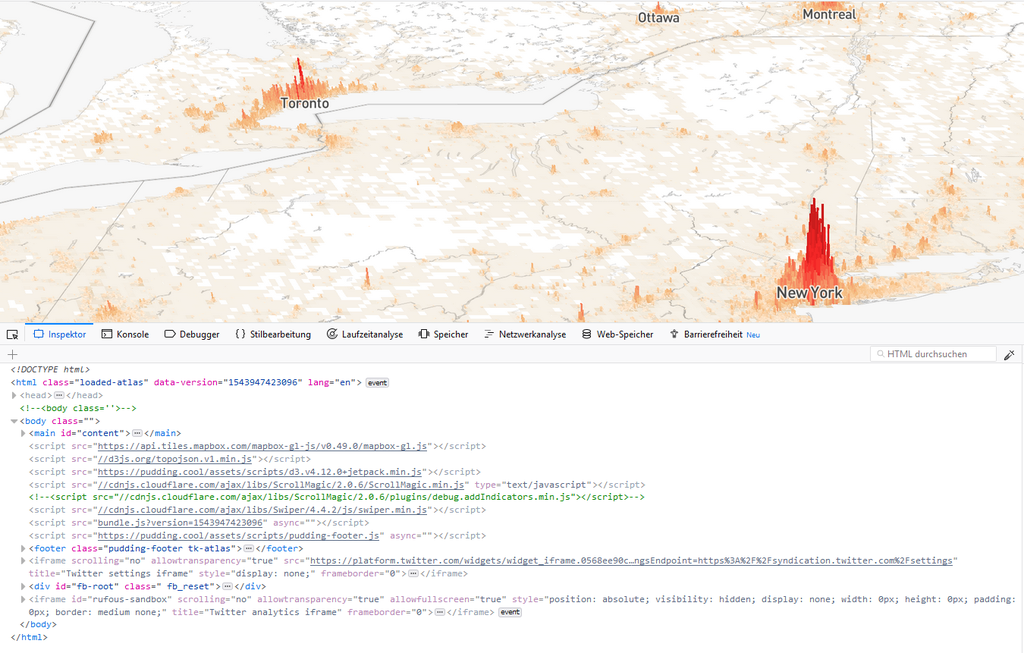

Quelle: [The Pudding (2018)](https://pudding.cool/2018/12/3d-cities-story/)

## 3a. Web Scraping (Toolbox)

Web Scraping-Projekte folgen einem generellen Schema:

1. Internetseite kennenlernen
2. Import von HTML-Dateien
3. Information isolieren
4. Iteration (loops)

Quelle: [Wickham & Grolemund (2018)](https://r4ds.had.co.nz/introduction.html)

## Web Scraping (Toolbox)

Das generelle Schema lässt sich in R über das Paket [`rvest`](https://github.com/hadley/rvest) umsetzen:

1. Kennenlernen der Internetseite [(u.a. `robotstxt`)](https://github.com/ropensci/robotstxt)
2. `read_html`: Import von HTML/XML-Dateien
3. Information isolieren
   - `html_nodes`: Extrahiert Teile des HTML-Dokument mit Hilfe von XPath/CSS-Selektoren
   - `html_text` / `html_attr` / `html_table`: Extrahiert Text, Attribute und Tabellen
4. `map` (package: [purrr](https://purrr.tidyverse.org/)): Iteration (loops)

[figure not shown]

## Beispiel: Sonntagsfrage

- Sonntagsfrage
  - von verschiedenen Umfrageinstituten erhoben [(Wahlrecht.de)](https://www.wahlrecht.de/umfragen/)
  - Archivfunktion (zeitlicher Verlauf)

Ziel: Aktuelle Umfragen aller Institute herunterladen und kombinieren.

[figure not shown]

Quelle: [Tagesschau.de](https://www.tagesschau.de/inland/deutschlandtrend/)

## (1) Kennenlernen der Internetseite

Fragen, die beantwortet werden sollten:

- statische oder dynamische Internetseite
  - statisch: [`rvest`](https://github.com/hadley/rvest)
  - dynamisch: [`RSelenium`](https://github.com/ropensci/RSelenium)
- Web Scraping erlaubt
  - Terms of Service (ToS)
  - robots.txt

## Wahlrecht: Kennenlernen der Internetseite

Hierzu gehört:

- Seitenquelltext: **statisch**
- HTML-Tags der Zielinformation: **table / class: wilko**
- robots.txt / Terms of Service: **keine relevanten Beschränkungen**

```r
paths_allowed(
  paths  = c("/index.htm","/allensbach.htm"),
  domain = c("wahlrecht.de")
)
```

```
##
 wahlrecht.de                      No encoding supplied: defaulting to UTF-8.
```

```
## [1] TRUE TRUE
```

## (2) Import von HTML-Dateien

Internetseiten müssen in ein Format übersetzt werden, welches von R gelesen und bearbeitet werden kann (z.B. Baumstruktur).

Benötigt wird:

- URL
- -> Request/Response-Paar

## Wahlrecht: Import von HTML-Seiten

Über `rvest::read_html`:

```r
(html.page <- read_html("https://www.wahlrecht.de/umfragen/allensbach.htm"))
```

```
## {xml_document}
## <html lang="de-DE">
## [1] <head>\n<meta http-equiv="expires" content="0">\n<meta http-equiv="c ...
## [2] <body>\n\n<div class="head">\n<table class="title" width="100%"><tr> ...
```

## (3) Information isolieren

Zur Extraktion von Informationen nutzen wir die Baumstruktur von HTML:

- [XPath](https://www.w3schools.com/xml/xpath_intro.asp)
- [CSS-Selektoren](https://www.w3schools.com/csSref/css_selectors.asp)

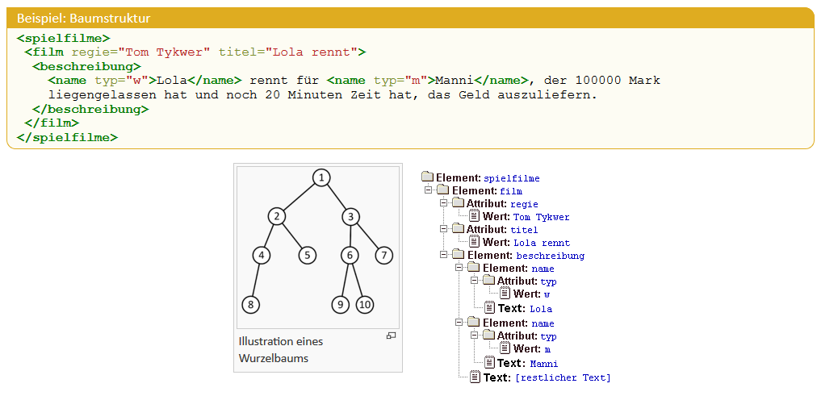

Quelle: [selfhtml.de](https://wiki.selfhtml.org/wiki/XML/Regeln/Baumstruktur)

## XPath und CSS-Selektoren: Tools

Wir konstruieren Selektoren selten manuell, da Anwendungen dies übernehmen.

Tools:

- [Selector Gadget](https://selectorgadget.com/)
- Browser: [Webentwicklungstools](https://developer.mozilla.org/de/docs/Tools/Seiten_Inspektor)
- Lerntools: [CSS Diner](https://flukeout.github.io/)

## Wahlrecht: CSS-Selektor

HTML-Tabellen lassen sich oft besonders leicht identifizieren, da sie das Tag “table” tragen:

```r
(html.node <- html_nodes(html.page, css = ".wilko"))
```

```
## {xml_nodeset (1)}
## [1] <table class="wilko" align="center" cellpadding="2" cellspacing="3"  ...
```

## Wahlrecht: Umwandeln in Text/Tabelle

Wir sind selten am HTML-Tag interessiert, sondern an dem Inhalt:

```r
html.table <- html.node %>%
  html_table(header = TRUE, fill = TRUE) %>%
  .[[1]] %>%                                 # body
  .[4:nrow(.), c(1, 3:9)] %>%                # subsetting
  glimpse()
```

```
## Observations: 67
## Variables: 8
## $ ``        <chr> "20.12.2018", "30.11.2018", "18.10.2018", "18.09.201...
## $ `CDU/CSU` <chr> "29,0 %", "28,0 %", "29,0 %", "31,5 %", "31,0 %", "3...
## $ SPD       <chr> "16,5 %", "17,0 %", "19,0 %", "19,5 %", "20,0 %", "2...
## $ GRÜNE     <chr> "19,0 %", "19,0 %", "15,0 %", "12,5 %", "12,5 %", "1...
## $ FDP       <chr> "8,5 %", "9,5 %", "8,5 %", "8,5 %", "9,0 %", "9,5 %"...
## $ LINKE     <chr> "9,0 %", "9,0 %", "9,0 %", "9,0 %", "9,0 %", "9,0 %"...
## $ AfD       <chr> "14,0 %", "13,5 %", "15,0 %", "15,0 %", "14,5 %", "1...
## $ Sonstige  <chr> "4,0 %", "4,0 %", "4,5 %", "4,0 %", "4,0 %", "4,0 %"...
```

## Exkurs: Regex

**Reg**ular **Ex**pression

- zur Suche von Ausdrücken (patterns) in Text (strings)
- in R z.B. über [`stringr`](https://stringr.tidyverse.org/index.html)

```r
str_view(string = "Wir benötigen nicht den gesamten Text,
         sondern nur die Zahl, welche sich im Text verbirgt: 42.",
         pattern = "[:digit:]+")
```

[interactive chart not shown]

[figure not shown]

## Wahlrecht: Regex

Die Umfrageergebnisse liegen als “strings” vor, sodass wir sie für die Datenanalyse in numerische Werte umwandeln müssen.

```r
str_view(string = html.table$`CDU/CSU`[1:5],
         pattern = "[:digit:]+,?[:digit:]?")
```

[interactive chart not shown]

## Datenaufbereitung

Wir ersetzen zudem die Kommata durch Punkte und wandeln die Daten in ein “long”-Format um:

```r
allensbach.df <- html.table %>%
  rename("Zeitpunkt" = 1) %>%                                 # 1. Variable benennen
  mutate(Zeitpunkt = parse_datetime(Zeitpunkt,                # 2. als Datum
                                    format = "%d.%m.%Y")) %>%
  mutate_if(is.character, str_extract,                        # 3a. Zahl entnehmen
            pattern = "[:digit:]+,?[:digit:]?") %>%
  mutate_if(is.character, str_replace,                        # 3b. Komma als Punkt
            pattern = ",", replacement = ".") %>%
  mutate_if(is.character, as.numeric) %>%                     # 3c. als Zahl
  gather(party, vote, -Zeitpunkt) %>%                         # 4. long format
  glimpse()                                                   # 5. ausgeben
```

```
## Observations: 469
## Variables: 3
## $ Zeitpunkt <dttm> 2018-12-20, 2018-11-30, 2018-10-18, 2018-09-18, 201...
## $ party     <chr> "CDU/CSU", "CDU/CSU", "CDU/CSU", "CDU/CSU", "CDU/CSU...
## $ vote      <dbl> 29.0, 28.0, 29.0, 31.5, 31.0, 30.5, 33.0, 34.0, 34.0...
```

## Visualisierung

Zuletzt können wir die Ergebnisse der Sonntagsfrage visualisieren (Paket: [`ggplot2`](https://ggplot2.tidyverse.org/)):

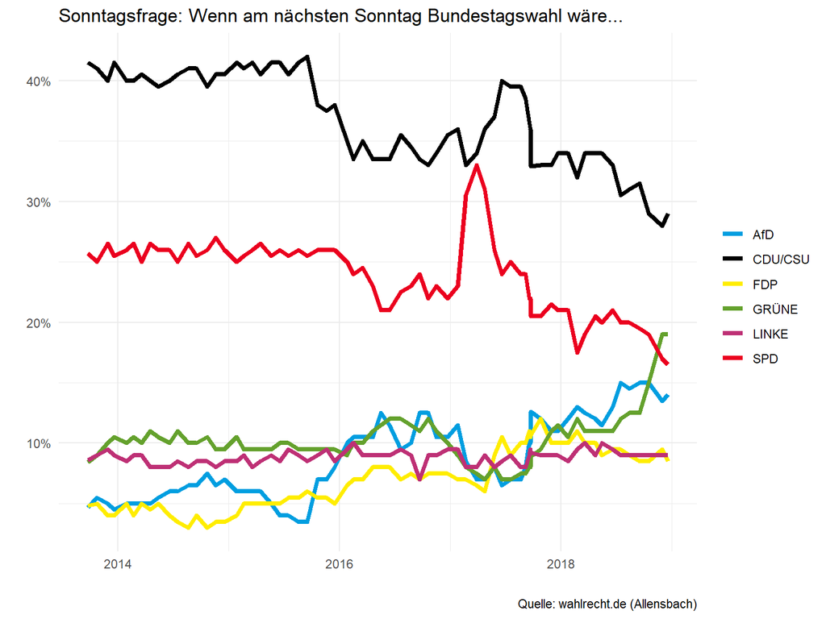

```r
ggplot(subset(allensbach.df, party != "Sonstige"),
       aes(x = Zeitpunkt, y = vote, colour = party)) +
  geom_line(size = 1.5) +
  scale_color_manual(values = c("#009EE0", "#000000", "#FFED00", "#64A12D",
                                "#BE3075", "#EB001F"),
                     guide = guide_legend(title = NULL)) +
  scale_y_continuous(labels = function(x) paste0(x, "%")) +
  labs(title = "Sonntagsfrage: Wenn am nächsten Sonntag Bundestagswahl wäre...",
       x = "", y = "", caption = "Quelle: wahlrecht.de (Allensbach)") +
  theme_minimal()
```

## (4) Iteration

Wird in den weiteren Anwendungen besprochen ([Code](https://github.com/FabianFox/Webscraping-Hamburg-/blob/master/Code/WahlrechtDe-Scraper.R))

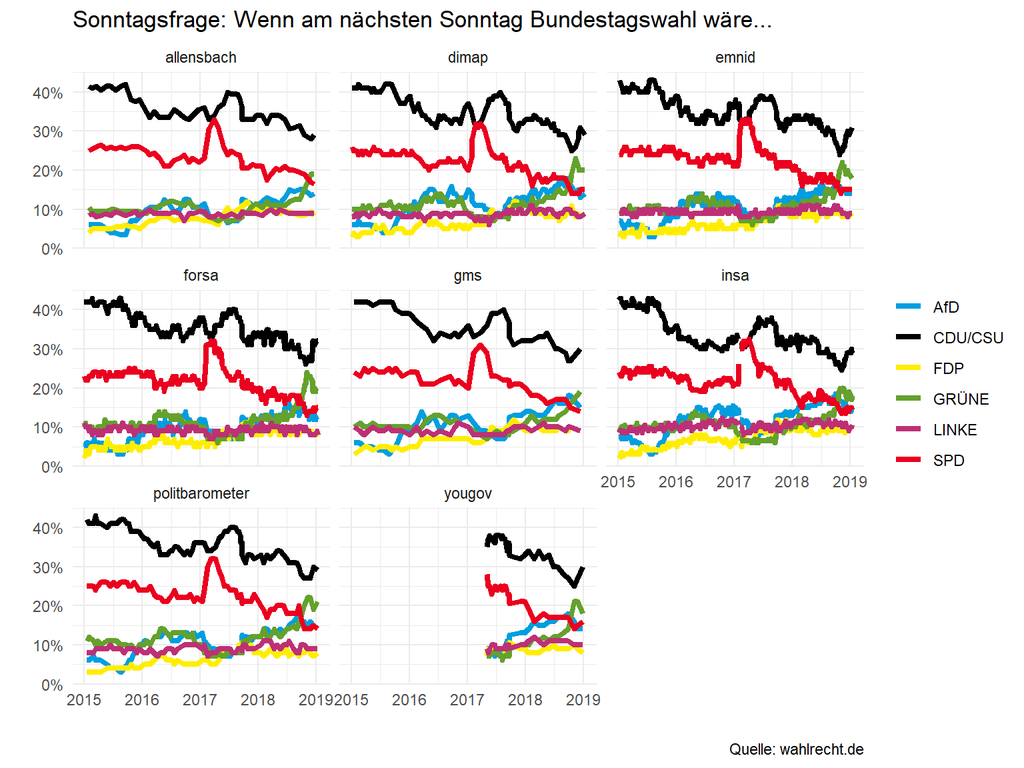

## 3b. Spezielle Technologien

Spezielle Möglichkeiten & Herausforderungen:

[**A**pplication **P**rogramming **I**nterface (API)](https://en.wikipedia.org/wiki/Application_programming_interface)

- **erleichtert** den Zugriff auf Daten über spezifische Schnittstellen
  - Beispiele: [Twitter](https://developer.twitter.com/en.html), [Die Zeit](http://developer.zeit.de/index/), [Eurostat](https://ec.europa.eu/eurostat/web/json-and-unicode-web-services), [Wikipedia](https://github.com/Ironholds/WikipediR/)

Dynamische Webseiten & bot blocking:

- **erschwert** Zugriff, da Daten erst nach Nutzeranfragen erzeugt werden
  - Beispiele: Süddeutsche Zeitung (Archiv), ArtFacts

## APIs: Steigende Relevanz

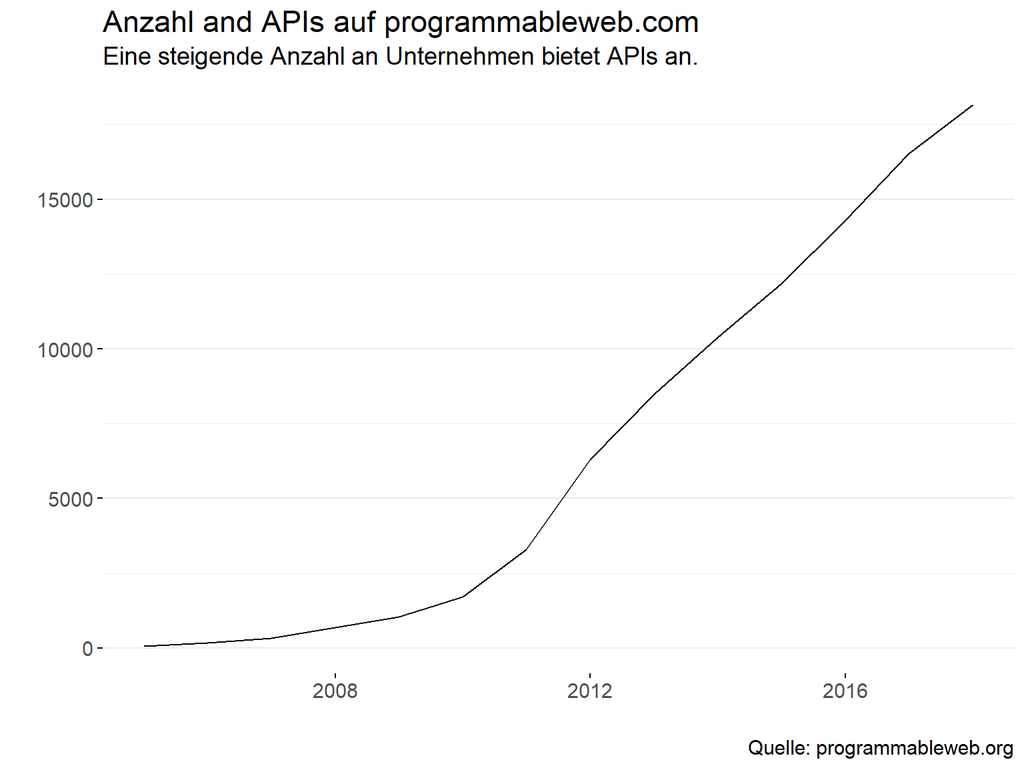

Quelle: Eigene Darstellung [(Code)](https://github.com/FabianFox/Webscraping-Hamburg-/blob/master/Code/programmableweb-Scraper.R)

## API: Eurostat

Eurostat bietet eine API für Datenbankabfragen an (Paket: [`eurostat`](https://ropengov.github.io/eurostat/))

Es gibt ein [“Cheatsheet”](https://github.com/rstudio/cheatsheets/raw/master/eurostat.pdf) für das Paket, welches das folgende Vorgehen beschreibt:

1. Suche nach [Daten](https://ec.europa.eu/eurostat/estat-navtree-portlet-prod/BulkDownloadListing?sort=1&file=table_of_contents_en.pdf) (`search_eurostat`)
2. Herunterladen der Daten (`get_eurostat`)
3. Datenaufbereitung (`tidyverse`)

## Beispiel: Eurostat

Arbeitslosenquote:

1. Daten suchen

```r
content <- search_eurostat(pattern = "unemployment rate", type = "dataset") %>%
  glimpse()
```

```
## Observations: 7
## Variables: 8
## $ title                         <chr> "Harmonised unemployment rates (...
## $ code                          <chr> "ei_lmhr_m", "lfst_r_lmdur", "lf...
## $ type                          <chr> "dataset", "dataset", "dataset",...
## $ `last update of data`         <chr> "10.01.2019", "22.10.2018", "22....
## $ `last table structure change` <chr> "10.01.2019", "18.07.2018", "18....
## $ `data start`                  <chr> "1983M01", "1999", "1999", "1995...
## $ `data end`                    <chr> "2018M12", "2017", "2017", "2017...
## $ values                        <chr> NA, NA, NA, NA, NA, NA, NA
```

2. Daten herunterladen

```r
unem.df <- get_eurostat(id = content$code[1],                  # Variable
                        time_format = "date",                  # Datumsformat
                        filters = list(s_adj = "NSA",          # Datenfilter
                                       indic = "LM-UN-T-TOT",
                                       geo = "EU28"),
                        stringsAsFactors = FALSE)
```

3. Datenaufbereitung

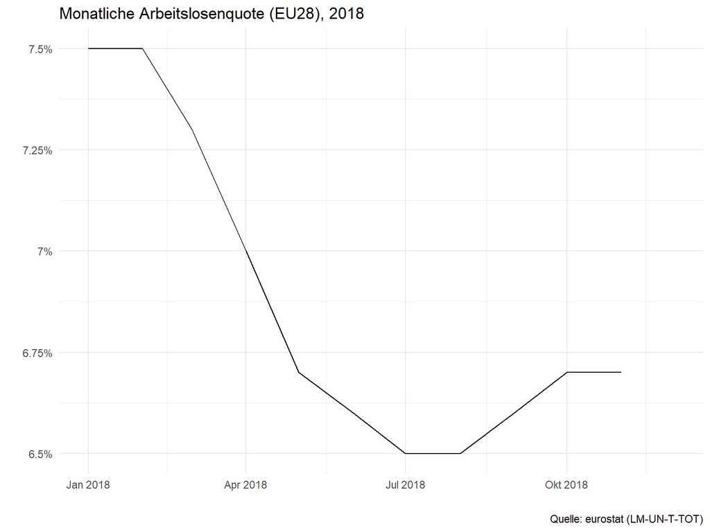

```r
# 3. Datenaufbereitung
unem.df %>%
  filter(time >= "2018-01-01") %>%
  ggplot() +
  geom_line(mapping = aes(x = time, y = values), stat = "identity") +
  scale_y_continuous(labels = function(x) paste0(x, "%")) +
  theme_minimal() +
  labs(title = "Monatliche Arbeitslosenquote (EU28), 2018",
       caption = "Quelle: eurostat (LM-UN-T-TOT)",
       x = "",
       y = "")
```

## 4. Rechtliche Aspekte

> “Big data? Cheap. Lawyers? Not so much.” (Pete Warden zit. in [Mitchell 2015: 217](http://shop.oreilly.com/product/0636920034391.do))
- rechtliche Grauzone
- länderspezifisch (USA: strikt; Deutschland: liberal)
- Terms of Service (ToS) beachten
- robots.txt prüfen

## 4. Rechtliche Aspekte in der Praxis

Ziel: “friendly scraping”

- Server nicht überlasten ([crawl delay](https://rud.is/b/2017/07/28/analyzing-wait-delay-settings-in-common-crawl-robots-txt-data-with-r/))
  - `Sys.sleep` einbauen (~5-10 Sekunden)
  - zufällige Wartezeit, um menschliches Verhalten zu imitieren
- Bot oder Mensch
  - “headless browsing”
    - RSelenium, decapitated, splashr oder htmlunit
- API nutzen (Sammlung unter [programmableweb.com](https://www.programmableweb.com/))
- Seitenbetreiber kontaktieren

## 5. Weitere Beispiele und Anwendungen

Weitere Beispiele:

- statische Seiten
  - [Gründerszene.de](https://github.com/FabianFox/Webscraping-Hamburg-/blob/master/Code/GruenderszeneDe-Scraper.R)
  - [Wahlrecht.de](https://github.com/FabianFox/Webscraping-Hamburg-/blob/master/Code/WahlrechtDe-Scraper.R)
  - [Studium.org](https://github.com/FabianFox/Webscraping-Hamburg-/blob/master/Code/SoziologieOrg-Scraper.R)
- dynamische Seiten
  - [ArtFacts.net](https://github.com/FabianFox/Webscraping-Hamburg-/blob/master/Code/ArtFacts-Scraper.R)
- APIs
  - [Twitter](https://github.com/FabianFox/Webscraping-Hamburg-/blob/master/Code/TwitterExample.R)

## 5. R-Setup

- benötigen [R](https://www.r-project.org/) und [RStudio](https://www.rstudio.com/products/rstudio/download/)
- Alternative: [RStudio Cloud](https://rstudio.cloud/)
  - derzeit kostenlos
  - läuft über den Browser (es muss nichts installiert werden)
  - (Einige) Beispiele können ausgeführt werden